# Experiment 4

2024-12-14

# Descriptive statistics

Count of of the answer choices in each condition

| CategoryType | Both | Is | Is not |
| --- | --- | --- | --- |
| Artifact | 93 | 53 | 136 |
| Clock | 7 | 1 | 39 |
| Comedian | 11 | 27 | 9 |
| Definite | 6 | 4 | 84 |
| Honeybees | 12 | 13 | 22 |
| Natural | 81 | 29 | 172 |
| Vague | 72 | 20 | 2 |
| Value | 118 | 71 | 93 |

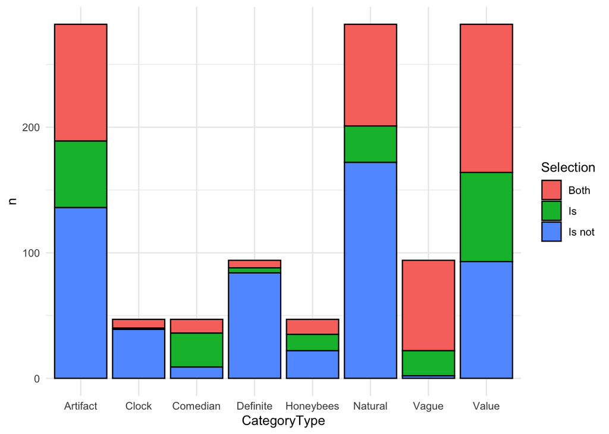

The distribution of selections for each category type

### The results of the model

Model structure: `brm(Selection ~ CategoryType + (CategoryType | Participant) + (1 | Item)`

`Selection` had three levels: “Both”,“Is not”, and “Is”. The model predicted the log-odds of each choice as a function of `CategoryType`.

`Participant`: There were 47 participants, each with 25 data points total (6 per `CategoryType`). the model included a random slope of category type per participant. This both takes into account the nested structure of the data and allows for the estimation of individual probabilities per `CategoryType`.

The table below reports the fixed effects and intercepts, as well as convergence metrics. This should be reported, but we won’t use this to make inferences directly.

| Parameter | Median | CI_low | CI_high | pd | ROPE_Percentage | Rhat | ESS |
| --- | --- | --- | --- | --- | --- | --- | --- |
| Intercept ‘is’ | -0.49 | -1.05 | 0.09 | 0.95 | 0.13 | 1 | 2126 |
| Intercept ‘is not’ | 2.48 | 1.53 | 3.42 | 1.00 | 0.00 | 1 | 1049 |
| Is_CategoryTypeArtifact | -1.13 | -1.93 | -0.35 | 1.00 | 0.00 | 1 | 2612 |
| Is_CategoryTypeNatural | -1.51 | -2.27 | -0.71 | 1.00 | 0.00 | 1 | 3665 |
| Isnot_CategoryTypeArtifact | 0.38 | -0.55 | 1.32 | 0.79 | 0.22 | 1 | 2186 |
| Isnot_CategoryTypeNatural | -6.42 | -7.45 | -5.42 | 1.00 | 0.00 | 1 | 3878 |

## The conditional effects based on the model

This plot and table were generated from the model using the `conditional_effects` function in R. The function just does the addition needed and conversion to probability as a convenience.

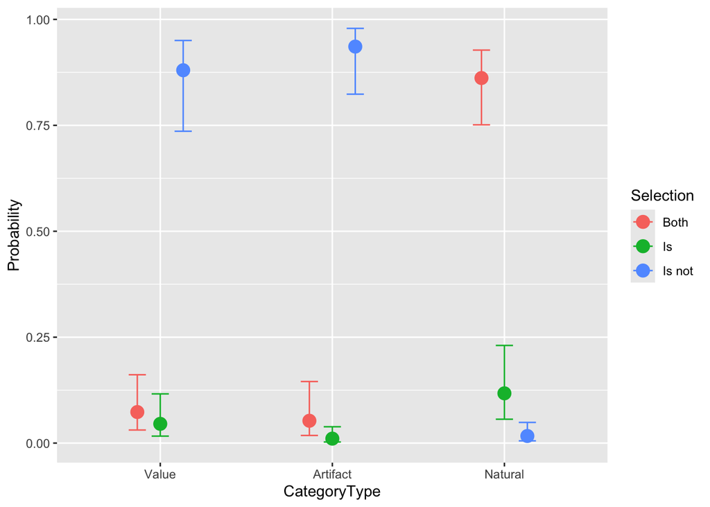

| CategoryType | Both | Is | Is not |
| --- | --- | --- | --- |
| Value | 0.07 [0.03 - 0.16] | 0.05 [0.02 - 0.12] | 0.88 [0.74 - 0.95] |
| Artifact | 0.05 [0.02 - 0.15] | 0.01 [0 - 0.04] | 0.94 [0.82 - 0.98] |
| Natural | 0.86 [0.75 - 0.93] | 0.12 [0.06 - 0.23] | 0.02 [0.01 - 0.05] |

# The pairwise comparisons

## Both-both across categories

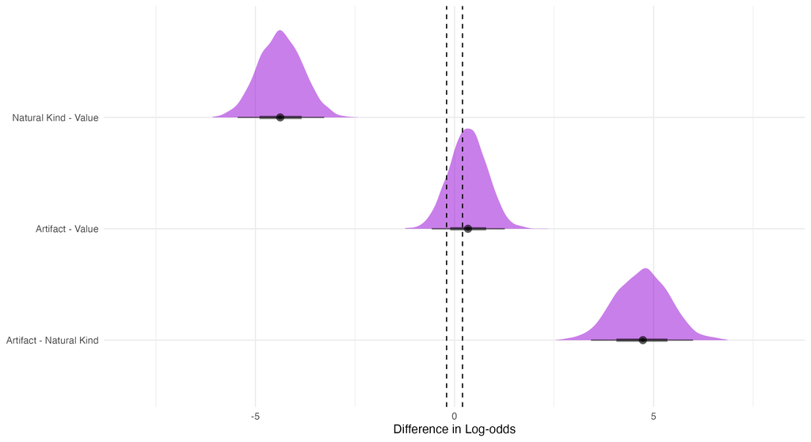

| Comparison | Effect | Compelling_difference |
| --- | --- | --- |
| Both_Natural_Both_Value | -4.37 [-5.5 - -3.34] | Yes |
| Both_Artifact_Both_Value | 0.34 [-0.61 - 1.2] | No |
| Both_Artifact_Both_Natural | 4.71 [3.43 - 5.99] | Yes |

# Is-is across categories

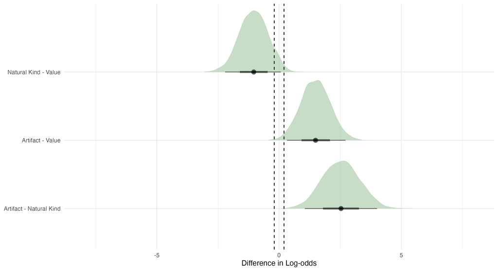

| Comparison | Effect | Compelling_difference |
| --- | --- | --- |
| Is_Natural_Is_Value | -1.04 [-2.13 - 0.14] | No |
| Is_Artifact_Is_Value | 1.49 [0.26 - 2.64] | Yes |
| Is_Artifact_Is_Natural | 2.53 [1.13 - 4.05] | Yes |

# Is not - is not across categories

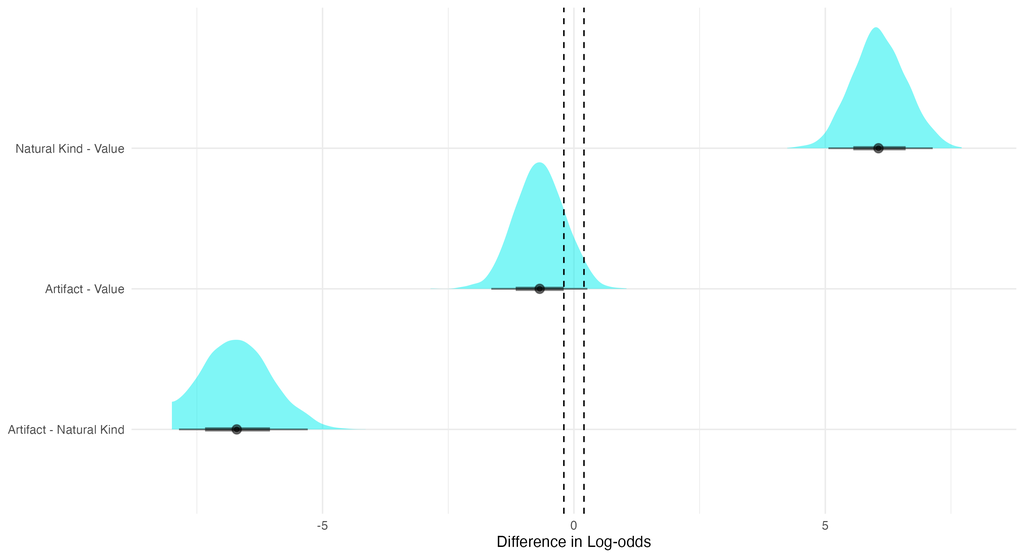

| Comparison | Effect | Compelling_difference |
| --- | --- | --- |
| Is not_Natural_Is not_Value | 6.07 [5.12 - 7.2] | Yes |
| Is not_Artifact_Is not_Value | -0.68 [-1.64 - 0.27] | No |
| Is not_Artifact_Is not_Natural | -6.75 [-8.14 - -5.27] | Yes |

# Both, is, is not within natural kinds

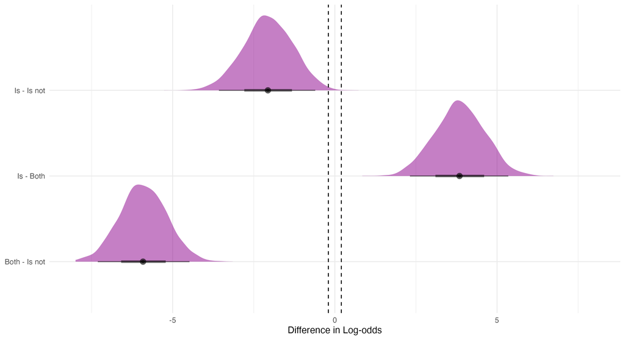

| Comparison | Effect | Compelling_difference |
| --- | --- | --- |
| Is_Natural_Is not_Natural | -2.06 [-3.52 - -0.58] | Yes |
| Is_Natural_Both_Natural | 3.85 [2.21 - 5.24] | Yes |
| Both_Natural_Is not_Natural | -5.91 [-7.32 - -4.49] | Yes |

# Both, is, is not within artifacts

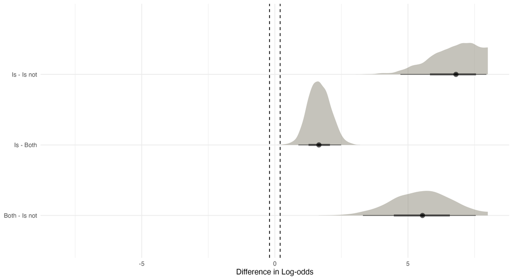

| Comparison | Effect | Compelling_difference |
| --- | --- | --- |
| Is_Artifact_Is not_Artifact | 7.22 [4.95 - 9.74] | Yes |
| Is_Artifact_Both_Artifact | 1.67 [0.89 - 2.49] | Yes |
| Both_Artifact_Is not_Artifact | 5.56 [3.39 - 7.9] | Yes |

# Both, is, is not within value

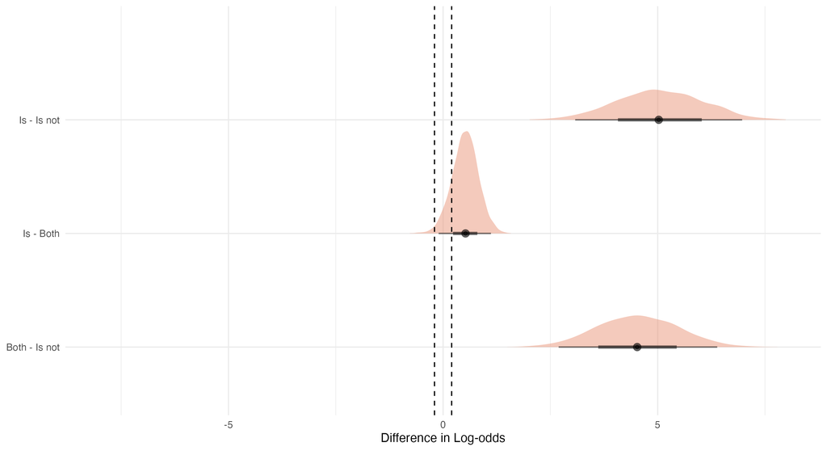

| Comparison | Effect | Compelling_difference |
| --- | --- | --- |
| Is_Value_Is not_Value | 5.05 [3.04 - 6.96] | Yes |
| Is_Value_Both_Value | 0.51 [-0.11 - 1.11] | No |
| Both_Value_Is not_Value | 4.54 [2.84 - 6.53] | Yes |

# Sensitivity analysis

| Parameter | Median | CI_low | CI_high | pd | ROPE_Percentage | Rhat | ESS |
| --- | --- | --- | --- | --- | --- | --- | --- |
| Intercept ‘is’ | -0.72 | -1.53 | 0.01 | 0.97 | 0.05 | 1 | 2003 |
| Intercept ‘is not’ | -0.53 | -1.50 | 0.42 | 0.88 | 0.16 | 1 | 1126 |
| Is_CategoryTypeArtifact | -0.46 | -1.82 | 0.69 | 0.77 | 0.19 | 1 | 1672 |
| Is_CategoryTypeNatural | -2.03 | -4.34 | -0.41 | 0.99 | 0.00 | 1 | 1087 |
| Isnot_CategoryTypeArtifact | 0.99 | -0.42 | 2.55 | 0.91 | 0.07 | 1 | 1021 |
| Isnot_CategoryTypeNatural | 1.64 | 0.21 | 3.18 | 0.98 | 0.00 | 1 | 1038 |

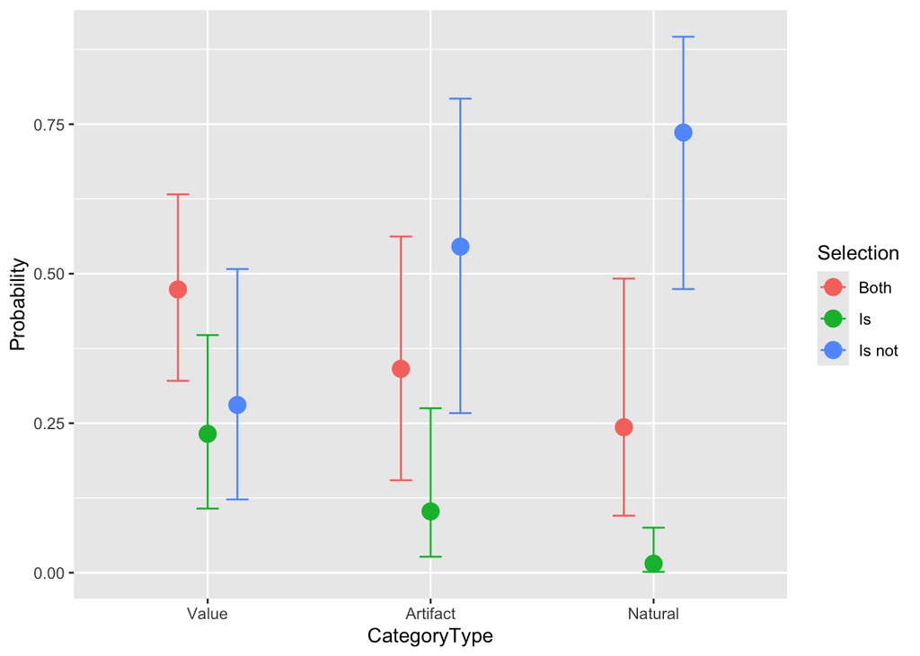

| CategoryType | Both | Is | Is not |
| --- | --- | --- | --- |
| Value | 0.47 [0.32 - 0.63] | 0.23 [0.11 - 0.4] | 0.28 [0.12 - 0.51] |
| Artifact | 0.34 [0.15 - 0.56] | 0.1 [0.03 - 0.28] | 0.55 [0.27 - 0.79] |
| Natural | 0.24 [0.1 - 0.49] | 0.02 [0 - 0.08] | 0.74 [0.47 - 0.9] |